# Análisis NLP de resoluciones de DDHH

TP Final, Manejo y Visualización de Datos

Autor/a

Avalos, Azuaga, Montalto, Paulucci

Fecha de publicación

17 de junio de 2026

**Código**

```r
library(tidyverse)
library(here)
library(tidytext)
library(udpipe)
library(tidylo)
library(countrycode)
```

Este notebook implementa la propuesta de análisis presentada al final del EDA. La idea es complementar el análisis cuantitativo de votos con un análisis del *contenido* de las resoluciones. La pregunta concreta: ¿hay diferencias sistemáticas en el vocabulario de las resoluciones que el bloque de países con alta dependencia comercial con China **apoya**, versus las que **rechaza o se abstiene**? Usamos TF-IDF y log odds ratio para identificar los términos más distintivos de cada grupo.

## 1 Importacion de datos

Cargamos cuatro insumos: el `dataset_final.rds` que produjo el 02 (para identificar los países de alta dependencia), y los tres archivos crudos de `unvotes` (textos de resoluciones, clasificación temática y votos individuales).

**Código**

```r
dataset_final <- readRDS(here("data/processed/dataset_final.rds"))
un_rollcalls  <- readRDS(here("data/raw/un_rollcalls_raw.rds"))
un_issues     <- readRDS(here("data/raw/un_issues_raw.rds"))
un_votes     <- readRDS(here("data/raw/unvotes_raw.rds"))
```

## 2 Definimos del bloque “de alta dependencia” y filtrado para resoluciones de DDHH

Definimos como “alta dependencia” a los países que en algún año estuvieron por encima del **percentil 75** de `china_dependence`. La elección del umbral es deliberada: con la mediana el bloque incluiría medio mundo y los contrastes se diluirían; con el percentil 90 quedarían poquísimos países y los resultados serían inestables. Después extraemos la lista de `rcid` de las resoluciones clasificadas como *Human rights*.

**Código**

```r
# 1. Definir umbral de alta dependencia (percentil 75, por ejemplo)
umbral <- quantile(dataset_final$china_dependence, 0.75, na.rm = TRUE)

# 2. Etiquetar países como alta o baja dependencia
paises_alta <- dataset_final |>
  filter(china_dependence >= umbral) |>
  distinct(iso3c) |>
  pull(iso3c)
# 3. Quedarse solo con los rcid de resoluciones de DDHH
rcid_ddhh <- un_issues |>
  filter(issue == "Human rights") |>
  pull(rcid)

length(rcid_ddhh)  # cuántas resoluciones de DDHH hay
```

```
[1] 1015
```

## 3 Clasificación de resoluciones

Para cada resolución de DDHH, calculamos qué proporción del bloque votó “no” o “abstain”. Si al menos la mitad del bloque rechaza o se abstiene, la resolución se clasifica como **rechaza_abstiene**; si menos de la mitad, como **apoya**. El resultado preliminar es elocuente: de 1015 resoluciones, 897 son apoyadas y solo 118 son rechazadas o abstenidas, lo cual ya sugiere que el bloque se alinea positivamente con la mayoría de las resoluciones de DDHH.

**Código**

```r
# Cómo votó el bloque de alta dependencia en cada resolución
votos_bloque <- un_votes |>
  mutate(iso3c = countrycode(country_code, origin = "iso2c", destination = "iso3c")) |>
  filter(iso3c %in% paises_alta,
         rcid %in% rcid_ddhh) |>
  group_by(rcid) |>
  summarise(
    prop_no_abs = mean(vote %in% c("no", "abstain"), na.rm = TRUE)
  ) |>
  mutate(
    grupo = if_else(prop_no_abs >= 0.5, "rechaza_abstiene", "apoya")
  )

# Verificar cuántas resoluciones quedaron en cada grupo
count(votos_bloque, grupo)
```

```
# A tibble: 2 × 2
  grupo                n
  <chr>            <int>
1 apoya              897
2 rechaza_abstiene   118
```

## 4 Unimos los textos de las resoluciones con la clasificación

Unimos los textos de las resoluciones (campo `descr`) con la clasificación que acabamos de construir, restringido al período **1995-2016** para mantener coherencia con el resto del análisis. De las 1015 resoluciones de DDHH totales, 469 caen dentro del período.

**Código**

```r
textos_clasificados <- un_rollcalls |>
  filter(rcid %in% rcid_ddhh,
         year(date) >= 1995, year(date) <= 2016) |>
  select(rcid, descr) |>
  inner_join(votos_bloque, by = "rcid")

# Verificar
glimpse(textos_clasificados)
```

```
Rows: 469
Columns: 4
$ rcid        <dbl> 3885, 3943, 3944, 3945, 3950, 3951, 3953, 3955, 3956, 3957…
$ descr       <chr> "Reaffirms the right of all persons displaced as a result …
$ prop_no_abs <dbl> 0.00000000, 0.23863636, 0.23595506, 0.02272727, 0.20224719…
$ grupo       <chr> "apoya", "apoya", "apoya", "apoya", "apoya", "apoya", "apo…
```

**Código**

```r
nrow(textos_clasificados)
```

```
[1] 469
```

## 5 Tokenización

`unnest_tokens()` rompe cada texto en palabras individuales y devuelve una fila por palabra. Cada palabra hereda el grupo (apoya / rechaza_abstiene) de la resolución de la que viene. Quedan 11.027 tokens

**Código**

```r
tokens <- textos_clasificados |>
  unnest_tokens(word, descr)

# Verificar
nrow(tokens)
```

```
[1] 11027
```

**Código**

```r
head(tokens)
```

```
# A tibble: 6 × 4
   rcid prop_no_abs grupo word
  <dbl>       <dbl> <chr> <chr>
1  3885           0 apoya reaffirms
2  3885           0 apoya the
3  3885           0 apoya right
4  3885           0 apoya of
5  3885           0 apoya all
6  3885           0 apoya persons
```

## 6 Eliminación de stopwords

Eliminamos las palabras vacías de significado (*the*, *of*, *and*, etc.) usando el diccionario `stop_words` de tidytext con un `anti_join`. También filtramos los tokens que son solo números (años, identificadores) que no aportan al análisis temático. Quedan 5.707 tokens.

**Código**

```r
data("stop_words")  # carga las stopwords incluidas en tidytext

tokens_limpios <- tokens |>
  anti_join(stop_words, by = "word") |>
  filter(!str_detect(word, "^[0-9]+$"))  # elimina números

# Verificar cuántas palabras quedan
nrow(tokens_limpios)
```

```
[1] 5707
```

## 7 Lematización

La lematización colapsa formas variantes de la misma palabra (*occupied / occupies / occupying* → *occupy*). Usamos el modelo de inglés de `udpipe`. El filtro final saca lemas muy cortos y un par de artefactos típicos de la lematización (`re`, `resol`).

**Código**

```r
#Descargamos el modelo de inglés
ud_model <- udpipe_download_model(language = "english")
ud_model <- udpipe_load_model(ud_model$file_model)
#Lematizamos
anotaciones <- udpipe_annotate(ud_model,
                                x = tokens_limpios$word,
                                doc_id = seq_along(tokens_limpios$word)) |>
  as.data.frame() |>
  select(doc_id, lemma) |>
  mutate(doc_id = as.integer(doc_id))

tokens_lematizados <- tokens_limpios |>
  mutate(doc_id = row_number()) |>
  left_join(anotaciones, by = "doc_id") |>
  select(-word) |>
  filter(nchar(trimws(lemma)) > 2,
       !lemma %in% c("re", "resol"))
```

## 8 TF-IDF

TF-IDF pondera cada lema por su frecuencia dentro del grupo (TF) y la rareza entre grupos (IDF). Los términos con TF-IDF más alto son los que aparecen mucho en un grupo y poco en el otro. En **apoya** dominan *palestinian*, *occupy*, *territory*, *israeli*, *jerusalem*, claramente asociados a las resoluciones sobre Israel-Palestina. En **rechaza_abstiene** aparecen *iran*, *islamic*, *cuba*, *turkmenistan*, países que las resoluciones suelen señalar como objeto de crítica.

**Código**

```r
#Calculamos el TF-IDF
tfidf <- tokens_lematizados |>
  count(grupo, lemma) |>
  bind_tf_idf(lemma, grupo, n) |>
  arrange(desc(tf_idf))
# Vemos los términos más distintivos de cada grupo
tfidf |>
  group_by(grupo) |>
  slice_max(tf_idf, n = 10) |>
  print(n = 20)
```

```
# A tibble: 48 × 6
# Groups:   grupo [2]
   grupo            lemma             n      tf   idf  tf_idf
   <chr>            <chr>         <int>   <dbl> <dbl>   <dbl>
 1 apoya            palestinian     135 0.0270  0.693 0.0187
 2 apoya            occupy           86 0.0172  0.693 0.0119
 3 apoya            territory        69 0.0138  0.693 0.00955
 4 apoya            practice         46 0.00919 0.693 0.00637
 5 apoya            determination    43 0.00859 0.693 0.00595
 6 apoya            include          43 0.00859 0.693 0.00595
 7 apoya            israeli          43 0.00859 0.693 0.00595
 8 apoya            exercise         36 0.00719 0.693 0.00498
 9 apoya            affect           35 0.00699 0.693 0.00485
10 apoya            jerusalem        34 0.00679 0.693 0.00471
11 rechaza_abstiene iran             22 0.0359  0.693 0.0249
12 rechaza_abstiene islamic          22 0.0359  0.693 0.0249
13 rechaza_abstiene cuba              5 0.00817 0.693 0.00566
14 rechaza_abstiene turkmenistan      3 0.00490 0.693 0.00340
15 rechaza_abstiene arabic            2 0.00327 0.693 0.00227
16 rechaza_abstiene belarus           2 0.00327 0.693 0.00227
17 rechaza_abstiene database          2 0.00327 0.693 0.00227
18 rechaza_abstiene adam              1 0.00163 0.693 0.00113
19 rechaza_abstiene asa               1 0.00163 0.693 0.00113
20 rechaza_abstiene assemby           1 0.00163 0.693 0.00113
# ℹ 28 more rows
```

## 9 Calculamos el Log Odds ratio

El log odds ratio ponderado (`bind_log_odds` de `tidylo`) es una métrica alternativa a TF-IDF que penaliza palabras raras con poca evidencia estadística. Da resultados parecidos pero más estables: confirma que **apoya** se asocia al léxico palestino-israelí, mientras que **rechaza_abstiene** se asocia a *iran* / *islamic* además de palabras genéricas (*right*, *human*, *situation*, *resolution*) que aparecen muy frecuentemente en este grupo.

**Código**

```r
log_odds <- tokens_lematizados |>
  count(grupo, lemma) |>
  bind_log_odds(grupo, lemma, n)

# Ver los más distintivos de cada grupo
log_odds |>
  group_by(grupo) |>
  slice_max(log_odds_weighted, n = 10) |>
  print(n = 20)
```

```
# A tibble: 20 × 4
# Groups:   grupo [2]
   grupo            lemma             n log_odds_weighted
   <chr>            <chr>         <int>             <dbl>
 1 apoya            palestinian     135              3.77
 2 apoya            occupy           86              2.99
 3 apoya            territory        69              2.67
 4 apoya            practice         46              2.17
 5 apoya            determination    43              2.10
 6 apoya            include          43              2.10
 7 apoya            israeli          43              2.10
 8 apoya            exercise         36              1.92
 9 apoya            affect           35              1.89
10 apoya            jerusalem        34              1.86
11 rechaza_abstiene right            60              6.81
12 rechaza_abstiene human            59              6.62
13 rechaza_abstiene situation        50              6.43
14 rechaza_abstiene resolution       46              6.31
15 rechaza_abstiene iran             22              6.14
16 rechaza_abstiene islamic          22              6.14
17 rechaza_abstiene adopt            33              5.26
18 rechaza_abstiene assembly         30              5.00
19 rechaza_abstiene republic         30              4.84
20 rechaza_abstiene draft            16              3.37
```

## 10 Visualizamos los datos obtenidos

El gráfico de abajo muestra los 15 lemas más distintivos de cada grupo según el log odds ratio ponderado, en paneles facetados.

**Código**

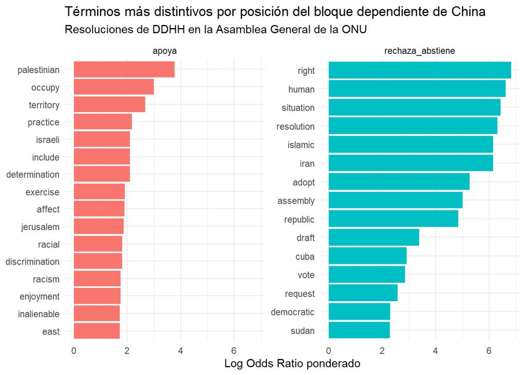

```r
log_odds |>
  group_by(grupo) |>
  slice_max(log_odds_weighted, n = 15) |>
  ungroup() |>
  mutate(lemma = reorder(lemma, log_odds_weighted)) |>
  ggplot(aes(x = log_odds_weighted, y = lemma, fill = grupo)) +
  geom_col(show.legend = FALSE) +
  facet_wrap(~grupo, scales = "free_y") +
  labs(
    title = "Términos más distintivos por posición del bloque dependiente de China",
    subtitle = "Resoluciones de DDHH en la Asamblea General de la ONU",
    x = "Log Odds Ratio ponderado",
    y = NULL
  ) +
  theme_minimal()
```

**Código**

```r
ggsave(here("output", "figures", "nlp_log_odds.png"),
       width = 10, height = 6, dpi = 300, bg = "white")
```

**Código**

```r
# Guardar la salida del análisis de texto para reutilizarla en 05_analisis.qmd
saveRDS(textos_clasificados, here("data/processed/textos_clasificados.rds"))
saveRDS(paises_alta, here("data/processed/paises_alta.rds"))
```

**Resultados principales.** El bloque de países con alta dependencia comercial con China apoya sistemáticamente las resoluciones sobre Palestina/Israel (*palestinian*, *occupy*, *territory*, *israeli*, *jerusalem*, *racial*, *discrimination*, *racism*). En cambio, rechaza o se abstiene en resoluciones que apuntan a países donde China tiene intereses estratégicos o ideológicos: Irán (*iran*, *islamic*), Cuba y Sudán. La diferencia es coherente con la hipótesis del trabajo: el voto del bloque no es aleatorio sino que sigue un patrón temático identificable. Esto refuerza el hallazgo del EDA (mayor `pct_yes` entre países de alta dependencia) agregando una dimensión cualitativa: qué tipo de resoluciones se apoyan y cuáles se rechazan.

## 11 Conclusiones

El análisis NLP confirma cualitativamente la dirección que sugería el EDA. Los países con alta dependencia comercial con China muestran un patrón de voto en DDHH **selectivo, no uniforme**: apoyan masivamente la agenda crítica hacia Israel (donde China sostiene una postura pública alineada con esta posición) y rechazan o se abstienen en resoluciones que apuntan a Irán, Cuba y Sudán, países con los que China tiene relaciones estratégicas o ideológicas. Esto sugiere que el factor “dependencia comercial” tiene mayor poder explicativo cuando se cruza con la **afinidad estratégica** entre China y el país objeto de la resolución, una dimensión que el análisis cuantitativo del 03 no captura. Una posible profundización para la segunda entrega sería incorporar variables de alineación política o ideológica para separar el efecto comercial puro del efecto de alineación con la política exterior china.